# Geodesic Skeleton Row-Family Comparison

# Purpose

This report isolates the new geodesic-skeleton row family from the denser local composite-geodesic operator. The skeleton construction starts with a graph diameter path, adds geodesics from poorly covered vertices back to the current skeleton, and optionally adds local cross-connectors between nearby skeleton paths. Along each selected geodesic, the operator places ordinary one-dimensional sliding-window annihilator rows.

The central diagnostic is coverage multiplicity,

$$c(v)=\#\{\gamma_s: v\in\gamma_s\},$$

together with the resulting operator size and nullity. A useful skeleton should be much sparser than the local composite operator while still preserving enough coverage to constrain the graph.

# Deterministic Micro-Validation

The first check uses graphs where the expected behavior is visible by inspection: a path graph, a three-arm star, and a rectangular grid. On the path graph, a diameter-only skeleton should reproduce the usual 1D sliding windows. For annihilator degree $d$, the expected path nullity is

$$\dim\ker(A)=d+1.$$

The star and grid tests do not have a single obvious polynomial nullity target; they are coverage tests. The star checks branch coverage, while the grid checks whether cross-enrichment raises coverage beyond a tree-like skeleton.

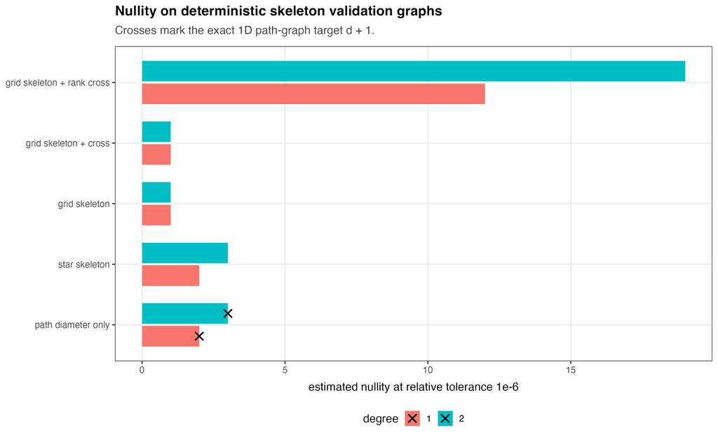

The path graph is the strict parity check: if that bar misses the cross, the skeleton row generator is not reproducing ordinary one-dimensional sliding windows. The star and grid values should be read as structural diagnostics. A large nullity means the skeleton is sparse and leaves many functions unconstrained; a smaller nullity after cross-enrichment means connector paths are adding real constraints.

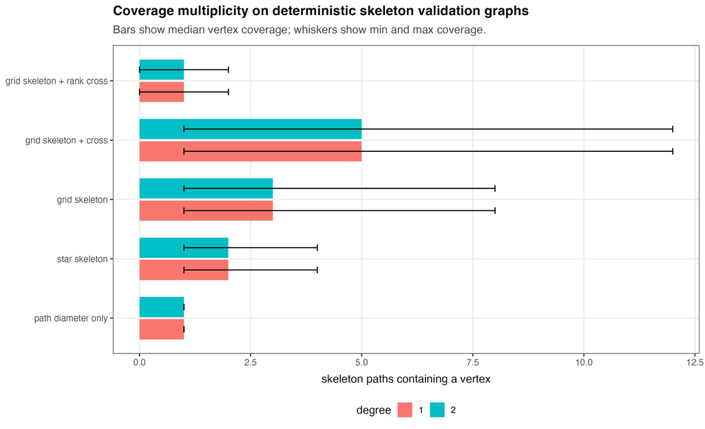

Coverage is the first thing to inspect before interpreting nullity. On path graphs, one diameter path is enough. On branching or grid-like graphs, low coverage identifies where a purely tree-like skeleton may underconstrain transverse behavior.

# Skeleton Paths In Sampled Graphs

The experiment RDS records each selected skeleton path and its role. The first path is the diameter. Coverage passes add geodesics from poorly covered vertices to the skeleton, and the cross-enriched family adds local connector paths.

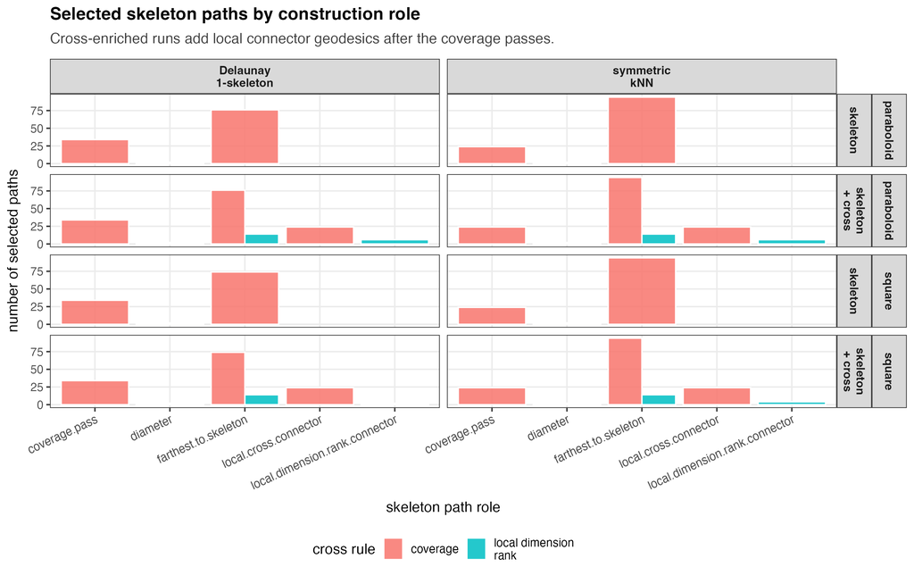

This plot tells us whether the skeleton is dominated by the initial diameter, coverage paths, or cross-connectors. For two- and three-dimensional sampled graphs, a report with only diameter and coverage paths is usually too tree-like; connector paths are the mechanism that begins to add transverse constraints.

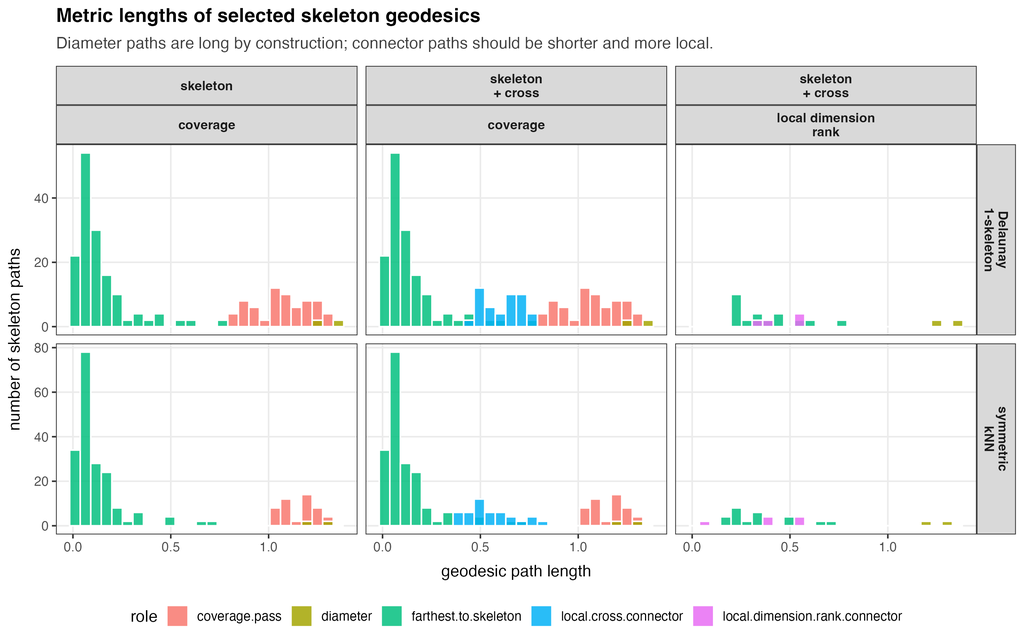

The intended pattern is long diameter paths, medium coverage paths, and shorter local cross-connectors. If connector paths are as long as the diameter, the cross-enrichment rule is no longer local and should be tightened.

# Coverage In Sampled Graphs

The next diagnostic looks directly at vertex coverage. This is more important than the number of paths, because a few long paths can give high path counts while still leaving many vertices poorly constrained.

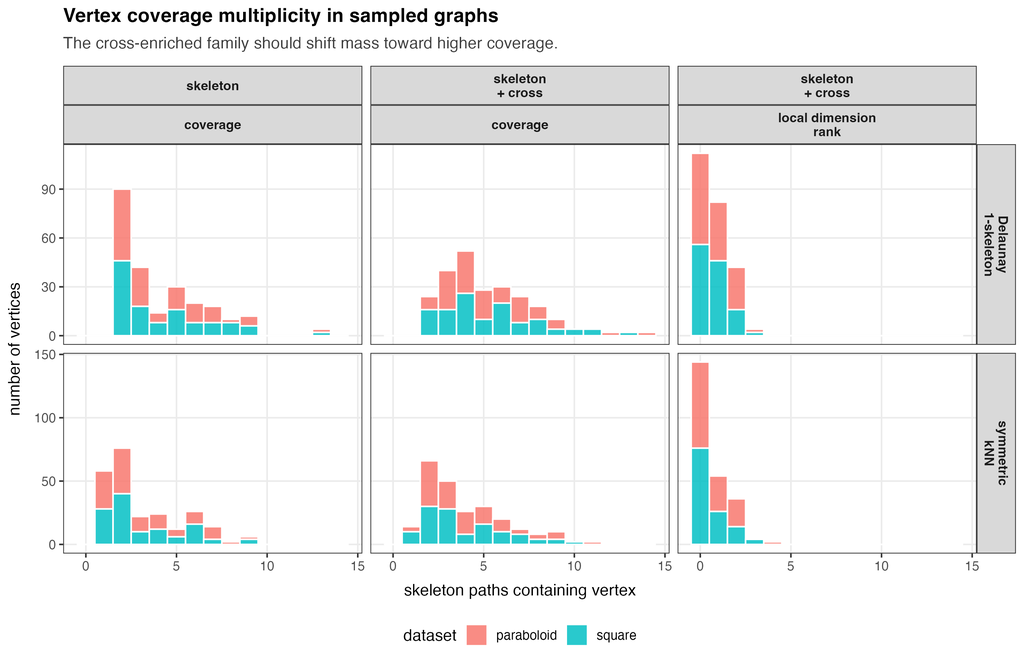

The current skeleton rule is deterministic and sparse. Its main failure mode is therefore visible here: vertices with low coverage or zero row coverage. These regions are the natural targets for the next cross-enrichment and thinning experiments.

# Local Direction-Rank Enrichment

The rank-aware cross rule estimates a local disk dimension $m_v$, embeds the disk in local coordinates, and measures how many independent skeleton directions are already present. If the local skeleton directions have rank $r_v<m_v$, the algorithm searches for connector geodesics between distinct skeleton paths and prefers connectors that increase directional rank:

$$\mathrm{deficit}(v)=(m_v-r_v)_+.$$

This diagnostic shows whether the new rule is actually finding local rank deficits and whether accepted connectors reduce those deficits.

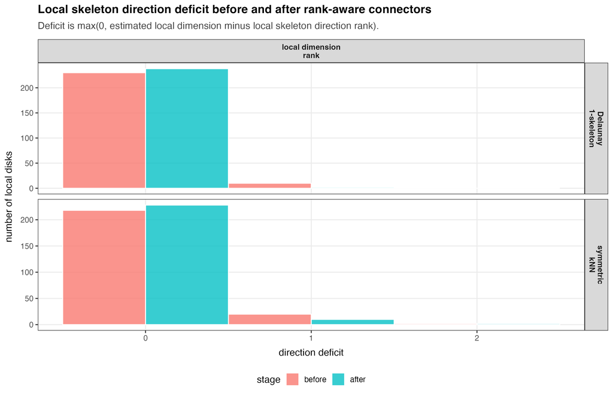

If the after distribution shifts left, the rank-aware connectors are doing their intended job. If many disks remain deficient, either the candidate connector pool is too small or the local dimension estimate is asking for more directions than the skeleton can provide at this radius.

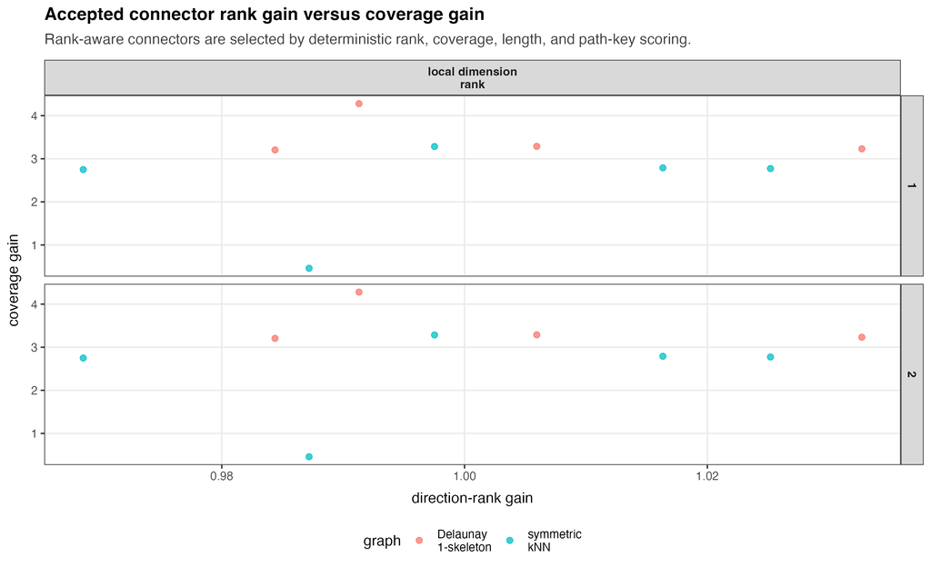

Rank gain is the primary criterion. Coverage gain is still useful because a connector that spans a missing direction but never reaches poorly covered vertices may have little effect on the final row operator.

# Operator Size And Nullity

The skeleton family is meant to be a sparse comparator, not a drop-in replacement for the local composite-geodesic operator. The plot below compares operator row counts and nullities across row families.

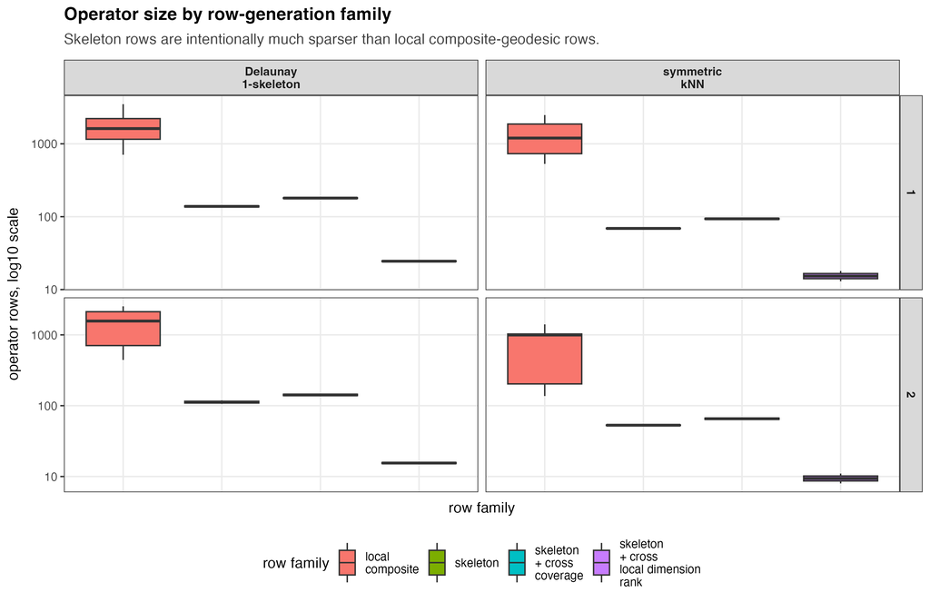

The useful regime is not simply “fewest rows.” If the skeleton operator is too sparse, nullity stays high and the graph remains underconstrained. The next plot asks whether cross-enrichment moves nullity in the expected direction.

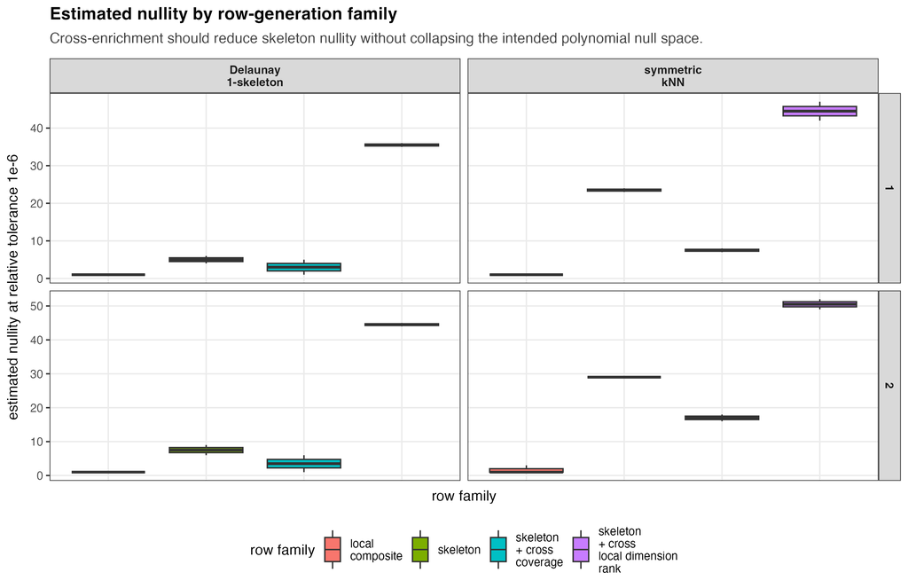

High skeleton nullity means the selected paths do not yet constrain enough graph directions. Very low nullity can mean the operator is overconstraining the graph and destroying the desired polynomial-like null space. The next methodological step is to use local dimension diagnostics to decide where cross-connectors are needed, instead of adding them only from graph-only coverage proxies.

# Discussion

The skeleton implementation gives us a clean experimental comparator. The diameter-only behavior on path graphs checks the one-dimensional sliding-window mechanism, while the star and grid examples expose the central modeling issue: one skeleton pass behaves like a tree approximation. Coverage-based cross-enrichment increases coverage and reduces nullity using graph-only heuristics.

The rank-aware cross rule is the next step toward a geometry-controlled row-generation strategy. In a disk whose estimated intrinsic dimension is $m_v$, it asks whether the selected skeleton directions span approximately $m_v$ independent directions. When they do not, it adds connector paths that are scored by direction-rank gain, coverage gain, length, and deterministic path keys. The main question for subsequent experiments is whether this local rank criterion improves polynomial residuals without collapsing the intended polynomial-like null space.

# Appendix

## Input Artifact

```r
rds.path
```

```
## [1] "/Users/pgajer/current_projects/gflow/dev/graph-trend-filtering/reports/geodesic_annihilator_smoke.rds"
```

```r
diagnostics$created
```

```
## [1] "2026-05-18 05:01:27 EDT"
```

## Deterministic Validation Table

```r
validation.table
```

```
##                         graph  n degree                      path.family
## 1          path diameter only 14      1                geodesic.skeleton
## 2               star skeleton 16      1                geodesic.skeleton
## 3               grid skeleton 36      1                geodesic.skeleton
## 4       grid skeleton + cross 36      1 geodesic.skeleton.cross.enriched
## 5  grid skeleton + rank cross 36      1 geodesic.skeleton.cross.enriched
## 6          path diameter only 14      2                geodesic.skeleton
## 7               star skeleton 16      2                geodesic.skeleton
## 8               grid skeleton 36      2                geodesic.skeleton
## 9       grid skeleton + cross 36      2 geodesic.skeleton.cross.enriched
## 10 grid skeleton + rank cross 36      2 geodesic.skeleton.cross.enriched
##    n.operator.rows nullity.1e.6 n.skeleton.paths  skeleton.cross.rule
## 1               12            2                1                 none
## 2               30            2                4                 none
## 3               77            1               27                 none
```

[output cut: 18 more lines]

## Skeleton Path Table

```r
head(skeleton.table, 60)
```

```
##    skeleton.path.id skeleton.pass        skeleton.role source target attach
## 1                 1             0             diameter      6     22     NA
## 2                 2             1 farthest.to.skeleton      2     41      2
## 3                 3             1 farthest.to.skeleton     25     27     25
## 4                 4             1 farthest.to.skeleton     53     49     53
## 5                 5             1 farthest.to.skeleton     27     15     27
## 6                 6             1 farthest.to.skeleton      1     30      1
## 7                 7             1 farthest.to.skeleton     13     50     13
## 8                 8             1 farthest.to.skeleton     49     11     49
## 9                 9             1 farthest.to.skeleton     15      7     15
## 10               10             1 farthest.to.skeleton     40     31     40
## 11               11             1 farthest.to.skeleton      4     54      4
## 12               12             1 farthest.to.skeleton      6     24      6
## 13               13             1 farthest.to.skeleton     30     12     30
## 14               14             1 farthest.to.skeleton     15     56     15
```

[output cut: 229 more lines]

## Skeleton Coverage Table

```r
head(skeleton.coverage.table, 60)
```

```
##    vertex skeleton.coverage skeleton.distance row.coverage run.id dataset  n
## 1       1                 7                 0           15     33  square 60
## 2       2                 8                 0           13     33  square 60
## 3       3                 2                 0            0     33  square 60
## 4       4                 8                 0           20     33  square 60
## 5       5                 5                 0           15     33  square 60
## 6       6                 8                 0            7     33  square 60
## 7       7                 5                 0            8     33  square 60
## 8       8                 6                 0           18     33  square 60
## 9       9                 3                 0            4     33  square 60
## 10     10                 2                 0            1     33  square 60
## 11     11                 2                 0            0     33  square 60
## 12     12                 2                 0            1     33  square 60
## 13     13                 3                 0            3     33  square 60
## 14     14                 2                 0            1     33  square 60
```

[output cut: 168 more lines]

## Skeleton Direction Diagnostics Table

```r
head(skeleton.direction.table, 60)
```

```
##    center disk.radius n.disk.vertices local.dimension embedding.dim
## 1      35   0.3155419              16               2             2
## 2      24   0.4484987              16               2             2
## 3      31   0.2328510              16               2             2
## 4      38   0.2145701              16               2             2
## 5      39   0.3991303              16               2             2
## 6      46   0.3104749              16               2             2
## 7       7   0.3240825              16               2             2
## 8      18   0.3634078              16               2             2
## 9      23   0.3269451              16               2             2
## 10     28   0.4896282              16               2             2
## 11     37   0.3934794              16               2             2
## 12     43   0.3180654              16               2             2
## 13     47   0.4028686              16               2             2
## 14     55   0.2762242              16               3             3
```

[output cut: 412 more lines]

## Skeleton Connector Candidate Table

```r
head(skeleton.connector.candidate.table, 60)
```

```
##    center candidate.index source target            path path.length
## 1      55               1      1     40    1-5-38-48-40  0.35813882
## 2      55               2      5     40      5-38-48-40  0.24267772
## 3      55               3     16     40        16-33-40  0.19253388
## 4      55               4     20     40           20-40  0.15662994
## 5      55               5     33     40           33-40  0.14945811
## 6      55               6     40     44     40-48-38-44  0.23701394
## 7      46               1      4     11   4-35-50-18-11  0.53470747
## 8      46               2      4     18      4-35-50-18  0.39198014
## 9      55               1      1     50 1-5-44-55-46-50  0.54960363
## 10     55               2      5     50   5-44-55-46-50  0.42075773
## 11     55               3     38     50  38-44-55-46-50  0.42934005
## 12     55               4     40     50  40-25-59-35-50  0.45345388
## 13     55               5     48     50  48-16-55-46-50  0.40953522
## 14     19               1      7     19            7-19  0.24119304
```

[output cut: 290 more lines]